# What Make Metal Special? - A Comparasion between Metal and Rock

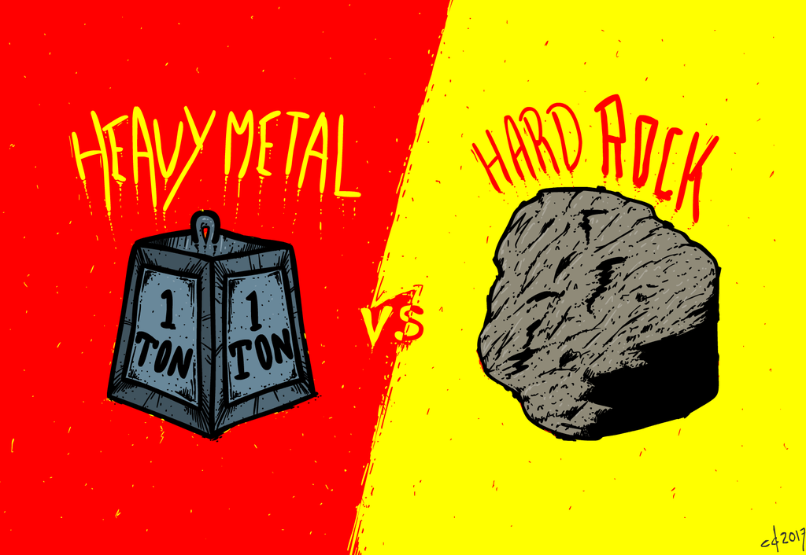

When I explore the data, Metal music quickly catches my eyes. While all other genres use “love” most frequently, Metal music writes more about “time” and “life”. I am curious about this type of music and did some research on that. To my surprise, it is a subgenre of rock music. However, in our dataset, these two types of music are well separated. Therefore, I want to explore how Metal is different from regular Rock music.

This report is prepared with the following environmental settings.

```
##                _
## platform       x86_64-apple-darwin15.6.0
## arch           x86_64
## os             darwin15.6.0
## system         x86_64, darwin15.6.0
## status
## major          3
## minor          6.0
## year           2019
## month          04
## day            26
## svn rev        76424
## language       R
## version.string R version 3.6.0 (2019-04-26)
## nickname       Planting of a Tree
```

First, I run the ‘Text_Processing.Rmd’ to clean the data. The procedure includes converting all the letters to the lower case, removing punctuation, numbers, empty words and extra white space, reducing words to their own stems, and resembling the structure of the original lyrics. The cleaned data is saved in the output folder as “processed_lyrics.RData”.

Then, I combine the processed_lyrics.RData with “artists.csv” which contains the artists information.

We are ready to go!

### Part I: Differences Between Metal and Rock on Word Choice

In the first part, I want to explore the difference between lyrics according to frequently used words.

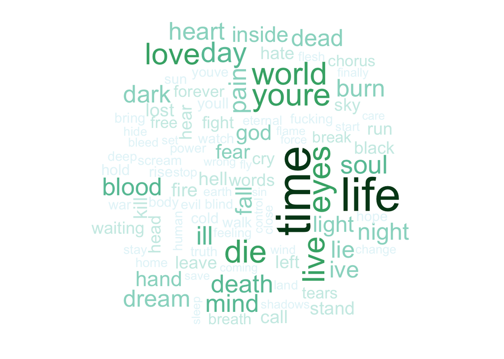

For Metal lyrics, “time” and “life” stand out. Besides that, we can see “die” “world”, “blood” etc are also used frequently, which shows a dark and depressing atmosphere.

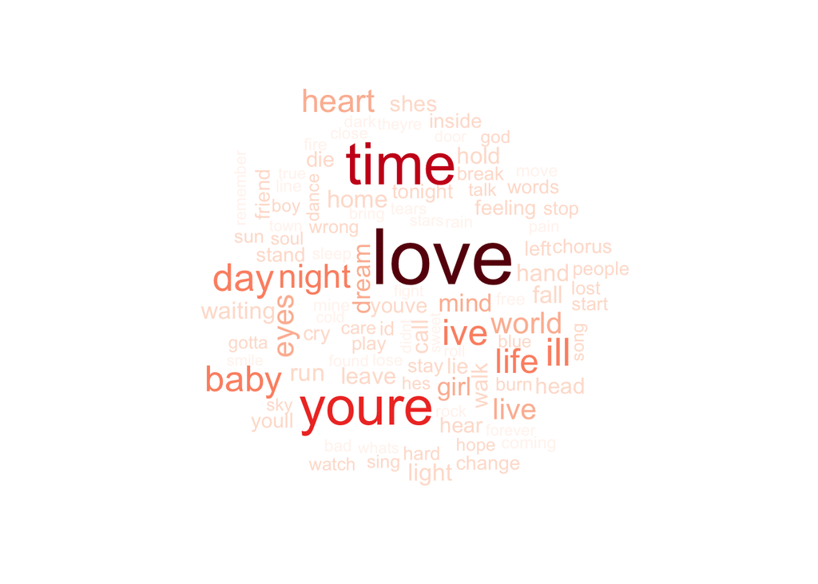

For Rock lyrics, “love”, “time” and “youre” are the top 3 highest frequency words. Most words that stand out are more relax than the Metal lyrics. For instance, “baby”, “day”, and etc.

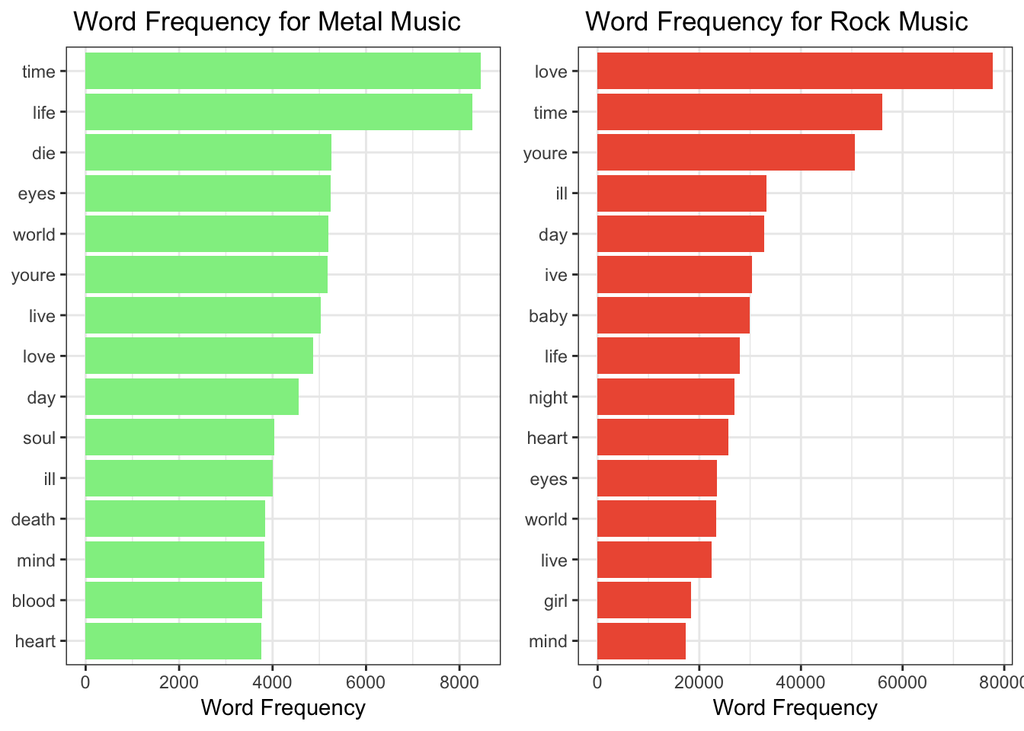

Then I take a closer look at the summary of the frequently used words for both genres. The top 5 words for Mental are different from Rock, suggesting that they may show different sentiments/topics. Also, by looking at 10-15 of both genres, we get some sense of what they are trying to express. In particular, Metal uses more aggressive words but Rock has more relax words.

Next, I try to visualize word in pairs, it help us see the connection between words.

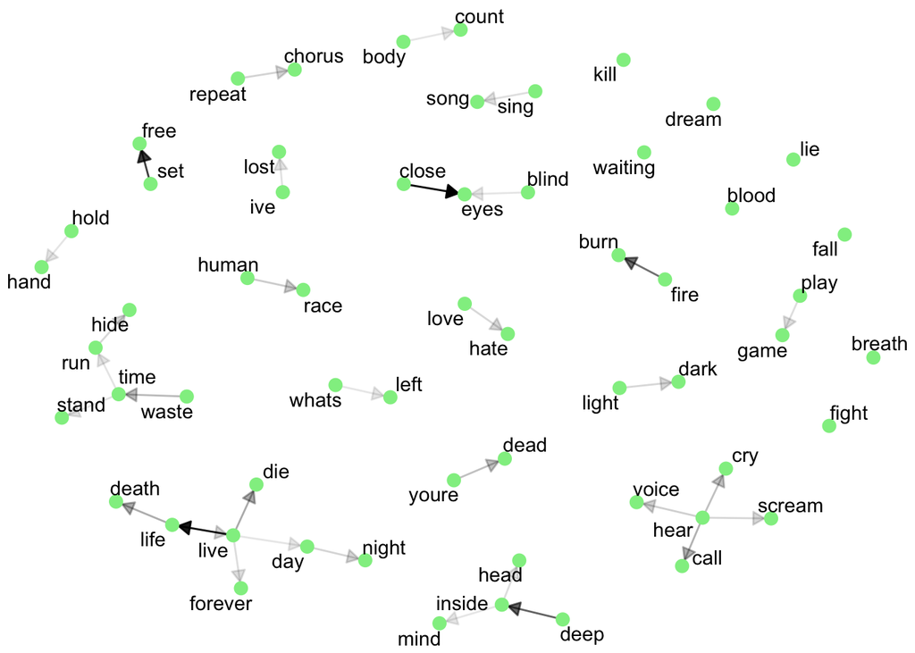

The plot above is the common bigram for Metal lyrics. There is one cluster focused on “life”. It connects with “death” and “live”. Besides that, it is hard to see any other obvious clusters. The information we can get is limited.

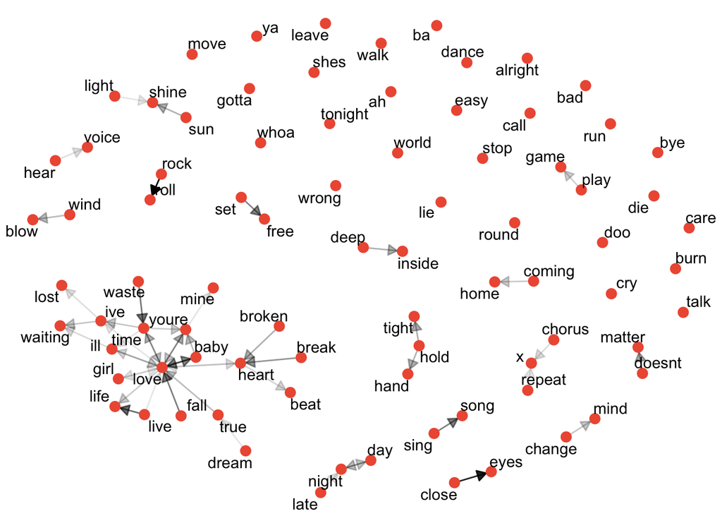

For Rock, “love” an obvious center, and the words connect to it are “baby”, “girl” and etc. Another cluster connects to it focused on “heart”. Therefore, Rock may have some relax or sad love song.

With a single word or bigram analysis, we can roughly tell the emotion or topic that each genre is trying to express. To be more accurate, we continue to evaluate the sentiment.

### Part II: Differences Between Metal and Rock on Sentiments

By simply looking at the high frequency words and words relation, we may guess the general emotion of each genre. In this section, I am trying to use sentiment analysis to evaluate the sentiments of lyrics to better summarize the characteristic of each genre.

First, I use bing lexicon which categorizes words in a binary fashion into positive and negative categories. I assign positive or negative sentiment to each word, count which sentiment dominates the lyrics, and assign it to the lyrics.

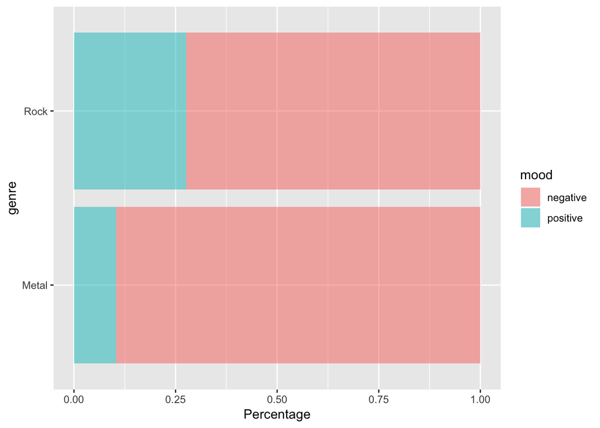

For both genres, most lyrics are negative. In particular, 90% Metal music is negative, which has a higher rate than negative Rock.

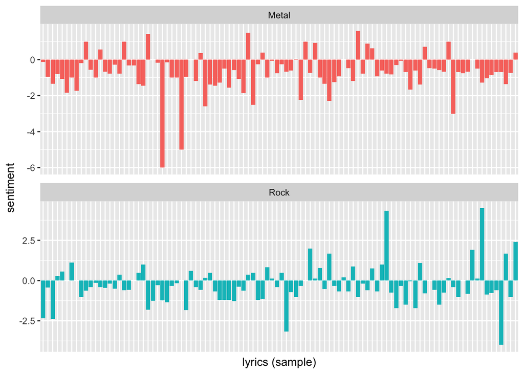

I randomly sample 100 lyrics for each genre, and plot their “sentiment score” by taking the mean of words’ value in the lyrics. Overall, Metal gets less and lower positive scores.

Then, I try to use nrc lexicon which gives more categories, including anger, anticipation, disgust, fear, joy, sadness, suprise, and trust.

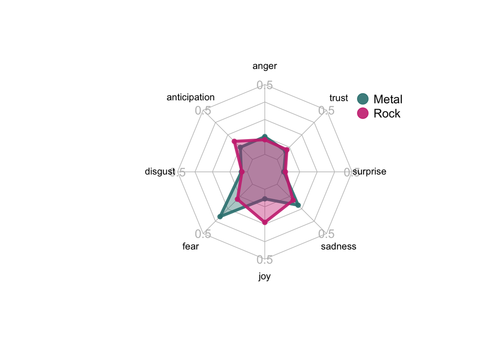

To show the proportion of each category in each genre, I use the radar plot. We can see that Metal lyrics show more fear, while Rock music express more joy.

Next, I calculate the proportion of each category in each year, and draw the heatmaps.

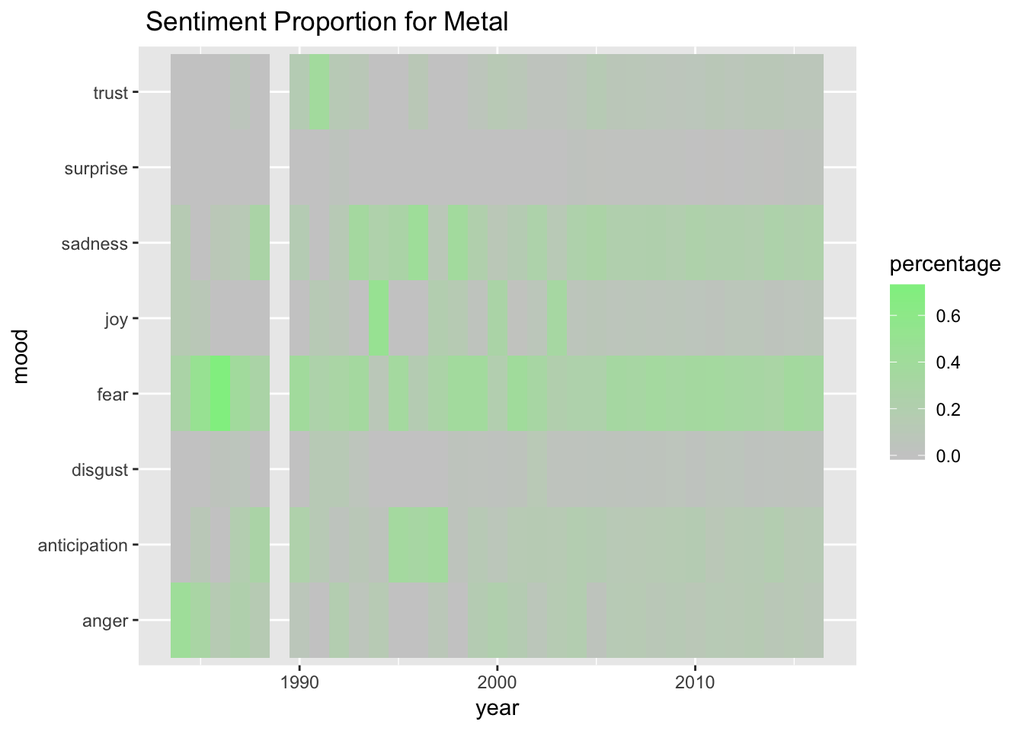

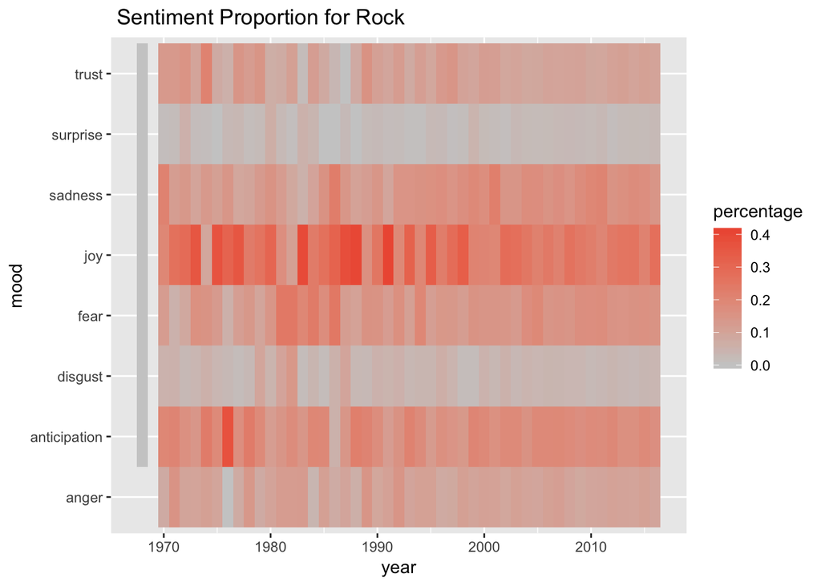

## Part III: What do Metal Artists “Fear” of?

Since most Metal lyrics are negative and express fear, my next step is to figure out what do Metal artists “fear” of? I try to answer this question by looking at all lyrics that express fear and the lyrics that contain fear and trying to find the top 3 topics among those lyrics.

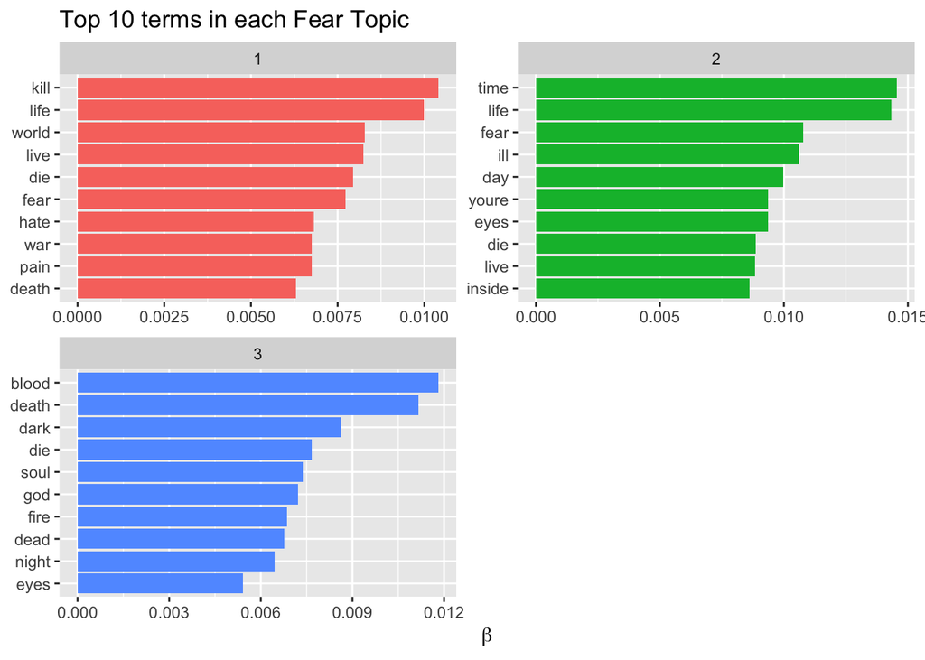

The first topic contains “kill”, “world”, “die”, “war”, and “pain”. They might belong to war and kill.

The second topic contains “time”, “life”, “ill”, “eyes”, and “inside”. They may refer to mental illness.

The third topic includes “blood”, “soul”, “god”. They might be summarized to religious topics.

Therefore, war, mental illness, and religious topic are three major topics that Metal artists are “fear” of.